# Case Study: Valorant Champions 2024

João Kishi

2025-02-27

# Introduction

##### The ESports gaming scene is growing exponentially over the years, and data comes in all shapes and forms when dealing with games. In this case study, we will be reviewing and analyzing data from the Valorant Champions 2024, by using tools like R and Excel, we’ll discover interesting stuff about players statistics as well as patterns and trends over the data.

##### The Valorant Champions 2024 was conquered by Edward Gaming (EDG) and the MVP was ZmjjKK

##### All data used was taken from Kaggle, from the [Valorant Champion Tour 2021-2024 Data](https://www.kaggle.com/datasets/ryanluong1/valorant-champion-tour-2021-2023-data) dataset by Ryan Luong. The data has 10.0 usability and is licensed by MIT, all data was scraped from vlr.gg.

# Loading libraries

```r
library(tidyverse)
library(ggplot2)
library(dplyr)
library(readr)
```

##### The libraries are used to process, analyze, and visualize data.

# Loading data

```r
## Load players_stats
players_stats <- read_csv("players_stats_filtered.csv")
## Load kills_stats
kills_stats <- read_csv("kills_stats_filtered.csv")
```

##### The data is loaded from two CSV files. Both datasets were cleaned in Excel, documentation here

# Processing data

```r
## Clean columns names
colnames(kills_stats) <- gsub(" ", "_", colnames(kills_stats))
colnames(players_stats) <- gsub(" ", "_", colnames(players_stats))

## Define team abbreviations mapping
team_abbreviations <- c("Gen.G" = "GEN", "Sentinels" = "SEN", "FunPlus Phoenix" = "FPX",
                        "Team Heretics" = "TH", "DRX" = "DRX", "KRÜ Esports" = "KRÜ",
                        "FNATIC" = "FNC", "Bilibili Gaming" = "BLG", "LEVIATÁN" = "LEV",
                        "Talon Esports" = "TLN", "Team Vitality" = "VIT", "Trace Esports" = "TE",
                        "G2 Esports" = "G2", "Paper Rex" = "PRX", "EDward Gaming" = "EDG",
                        "FUT Esports" = "FUT")
kills_stats <- kills_stats %>%
  mutate(Team_Abbreviations = team_abbreviations[Team])

## Adding rounds played per player to kills stats dataset
rounds_played_per_player <- players_stats %>%
  select(Player, Rounds_Played)
kills_stats <- left_join(kills_stats, rounds_played_per_player, by = "Player")

## Verifying data integrity
### Kills stats columns names.
colnames(kills_stats)
```

```
##  [1] "Tournament"         "Stage"              "Match_Type"
##  [4] "Match_Name"         "Map"                "Team"
##  [7] "Player"             "Agents"             "2k"
## [10] "3k"                 "4k"                 "5k"
## [13] "1v1"                "1v2"                "1v3"
## [16] "1v4"                "1v5"                "Econ"
## [19] "Spike_Plants"       "Spike_Defuses"      "Team_Abbreviations"
## [22] "Rounds_Played"
```

```r
### Players stats columns names.
colnames(players_stats)
```

```
##  [1] "Tournament"                     "Stage"
##  [3] "Match_Type"                     "Player"
##  [5] "Teams"                          "Agents"
##  [7] "Rounds_Played"                  "Rating"
##  [9] "Average_Combat_Score"           "Kills:Deaths"
## [11] "Kill,_Assist,_Trade,_Survive_%" "Average_Damage_Per_Round"
## [13] "Kills_Per_Round"                "Assists_Per_Round"
## [15] "First_Kills_Per_Round"          "First_Deaths_Per_Round"
## [17] "Headshot_%"                     "Clutch_Success_%"
## [19] "Clutches_(won/played)"          "Maximum_Kills_in_a_Single_Map"
## [21] "Kills"                          "Deaths"
## [23] "Assists"                        "First_Kills"
## [25] "First_Deaths"
```

```r
### Verifying if all teams have 5 players.
print(table(players_stats$Teams))
```

```
##
## Bilibili Gaming             DRX   EDward Gaming          FNATIC FunPlus Phoenix
##               5               5               5               5               5
##     FUT Esports      G2 Esports           Gen.G     KRÜ Esports        LEVIATÁN
##               5               5               5               5               5
##       Paper Rex       Sentinels   Talon Esports   Team Heretics   Team Vitality
##               5               5               5               5               5
##   Trace Esports
##               5
```

```r
### Verifying if all players on each team have the same matches.
print(table(players_stats$`Rounds_Played`))
```

```
##
##  78  85  88 115 140 151 153 156 200 208 238 293 361 407 449 552
##   5   5   5   5   5   5   5   5   5   5   5   5   5   5   5   5
```

##### Both datasets columns were cleaned to be snake cased.

##### The “Kills Stats” dataset didn’t have an abbreviation column, so it was made one, to be easier when analyzing and visualizing.

# Analyzing the data

## Creating max multikills list with players names and teams

```r
max_kills_list <- lapply(c("5k", "4k", "3k", "2k"), function(kill_type) {
  max_rows <- kills_stats[kills_stats[[kill_type]] == max(kills_stats[[kill_type]], na.rm = TRUE), ]
  data.frame(
    Kill_Type = kill_type,
    Player = max_rows$Player,
    Team_Abbreviations = max_rows$Team_Abbreviations,
    Max_Kills = max_rows[[kill_type]],
    Rounds_Played = max_rows$Rounds_Played,
    stringsAsFactors = FALSE
  )
})
max_kills <- do.call(rbind, max_kills_list)
```

```
##                Kill_Type Player Team_Abbreviations Max_Kills Rounds_Played
## EDward Gaming         5k ZmjjKK                EDG         2           449
## Gen.G                 4k Meteor                GEN         4           153
## G2 Esports            4k    icy                 G2         4           200
## EDward Gaming1        4k ZmjjKK                EDG         4           449
## LEVIATÁN              3k  aspas                LEV         8           407
## FNATIC                3k  Derke                FNC         8           293
## Team Heretics         2k  RieNs                 TH        24           552
## EDward Gaming2        2k ZmjjKK                EDG        24           449
```

##### This table contains all types of multikills (2k, 3k, 4k and 5k), the max count for each multikill each player did, their rounds played as well as their team.

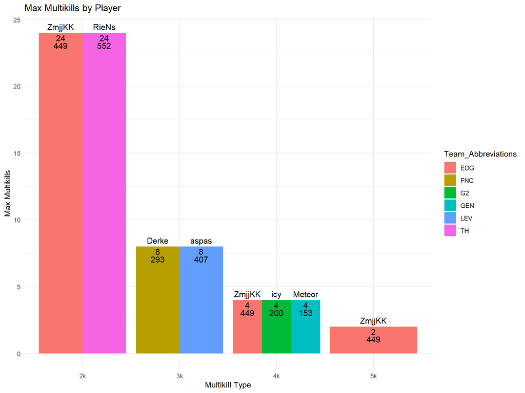

##### As we can see, ZmjjKK was the only player with 2 “aces” (5k), it is noticeable that he appears on the 4k list as well as the 2k list, making his performance throughout the championship remarkable.

##### We have players like GEN Meteor and G2 icy that have low rounds played but high multikills count.

## Creating max multikills list with players names and teams for grand final

```
##                Kill_Type  Player Team_Abbreviations Max_Kills Rounds_Played
## EDward Gaming         5k  ZmjjKK                EDG         2           449
## EDward Gaming1        4k  ZmjjKK                EDG         3           449
## EDward Gaming2        3k CHICHOO                EDG         6           449
## EDward Gaming3        2k  ZmjjKK                EDG        24           449
```

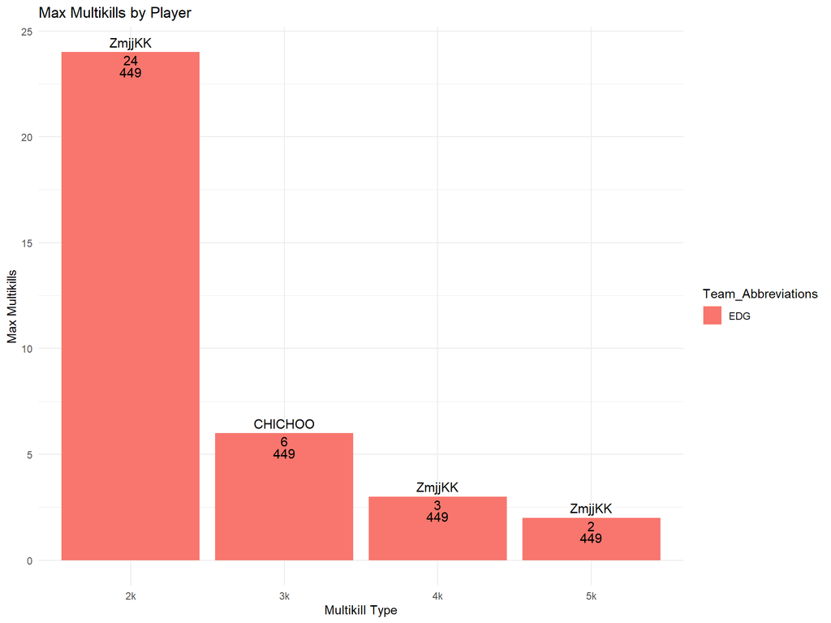

```r
# kills stats for only grand finals maps
grand_final_data <- kills_stats[kills_stats$`Match_Type` == "Grand Final", ]

max_kills_list <- lapply(c("5k", "4k", "3k", "2k"), function(kill_type) {
  max_rows <- grand_final_data[grand_final_data[[kill_type]] == max(grand_final_data[[kill_type]], na.rm = TRUE), ]
  data.frame(
    Kill_Type = kill_type,
    Player = max_rows$Player,
    Team_Abbreviations = max_rows$Team_Abbreviations,
    Max_Kills = max_rows[[kill_type]],
    Rounds_Played = max_rows$Rounds_Played,
    stringsAsFactors = FALSE
  )
})
max_kills_grand_final <- do.call(rbind, max_kills_list)
```

##### We can see the performance from EDG on the Grand Finals match, with the MVP ZmjjKK being the dominant name appearing on the most multikills in the match.

## Creating max clutches for grand finals match

```r
clutches_grand_final_list <- lapply(c("1v1", "1v2", "1v3", "1v4", "1v5"), function(clutches) {
  valid_rows <- grand_final_data[grand_final_data[[clutches]] > 0, ]
  if(nrow(valid_rows) > 0) {
    max_rows <- valid_rows[valid_rows[[clutches]] == max(valid_rows[[clutches]], na.rm = TRUE), ]
    return(data.frame(
      Clutches = clutches,
      Player = max_rows$Player,
      Team_Abbreviations = max_rows$Team_Abbreviations,
      Max_Clutches = max_rows[[clutches]],
      Rounds_Played = max_rows$Rounds_Played,
      stringsAsFactors = FALSE
    ))
  }
})
clutches_grand_final <- do.call(rbind, clutches_grand_final_list)
```

```
##               Clutches     Player Team_Abbreviations Max_Clutches Rounds_Played
## 1                  1v1     nobody                EDG            2           449
## 2                  1v1      S1Mon                EDG            2           449
## 3                  1v1        Boo                 TH            2           552
## EDward Gaming      1v2    CHICHOO                EDG            3           449
## 11                 1v3        Boo                 TH            1           552
## 21                 1v3      RieNs                 TH            1           552
## 31                 1v3 benjyfishy                 TH            1           552
```

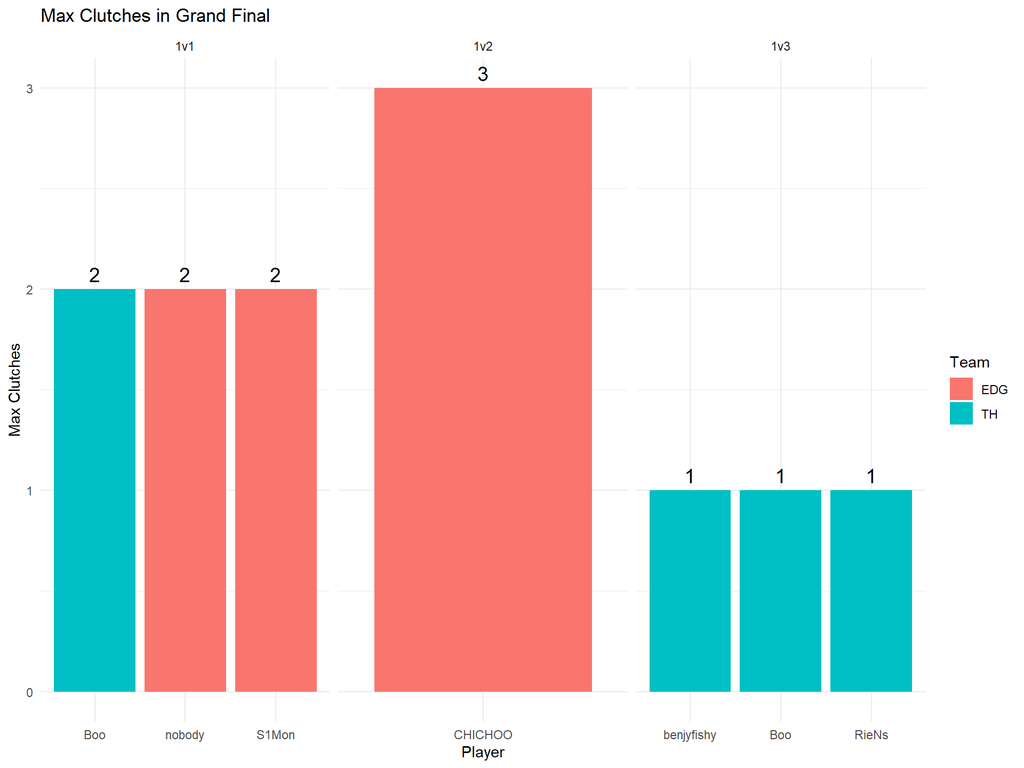

##### We can see that Team Heretics had more 1v3 clutches, but EDG had more clutches overall.